# District Middle School: Data Analysis and Plan

2-12-2018

## Finding 1

Student body size steadily decreased until most recent year when it increased. School climate indicators apear to show positive change in last year.

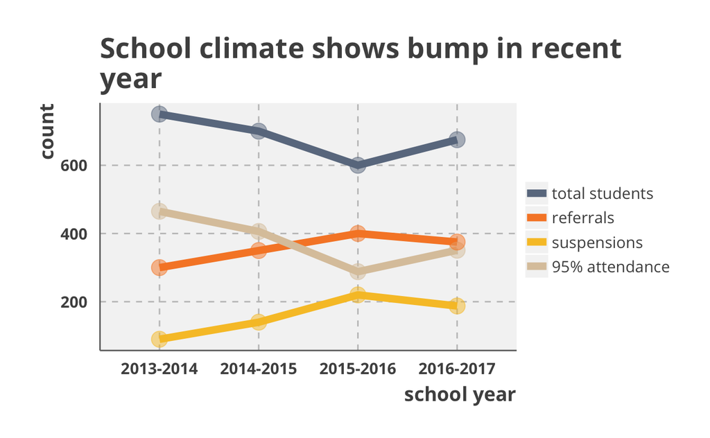

## Finding 2

Substantial increase in the percent of White students.

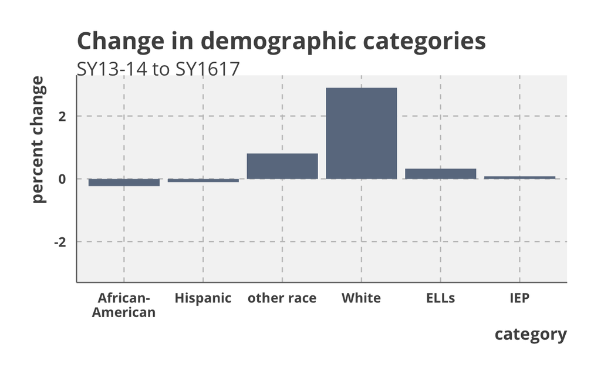

## Finding 3

Test scores decrease when the student body is more African-American, but increase with each other category.

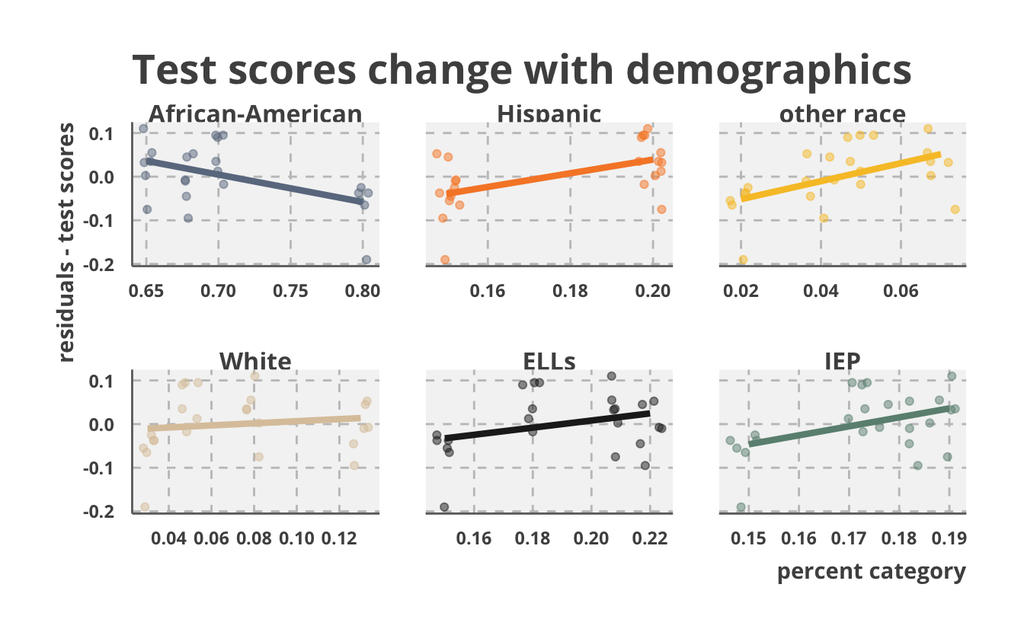

## Strategic Plan: Further Exploration

#### Evidence suggests that positive changes in recent year may not hold-up when viewed with equity lens

#### Next steps

- Disaggregate test score and discipline data by race
- Collect additional data through teacher observations and progress monitoring (such as CDT)
- Incoporate neighborhood context through census data

## Strategic Plan: Action Steps

- Encourage teacher collaboartion
  - time to review data
  - allow 6th grade reading teachers to share best practices
- Research and implement evidence-based intervention based on data review
  - priority in 7th grade mathematics
- Connect principal with mentor
- Engage parents through parent committee, digital communication, and APTT (below)
- Establish partnerships with community organizations particularly focused on attendance and student engagement

## Turnaround Principle 6: Safe school environment

#### Rationale

- High rates of discipline referrals and suspension
- Low rates of attendance
- Improvement in most recent year may or may not reflect true positive change

#### Work with principal to:

- Understand discipline procedures and systems
- Explore disagreggated discipline data and trends over time

## Turnaround Principle 6: Safe school environment

#### Implementation plan

- Conduct surveys of staff, students, and families
- Develop school-wide positive behavioral support system
  - focus on attendance
- Establish restorative practice procedures

## Parent tip

### Academic Parent-Teacher Teams (APTT)

Research validated program, developed by San Juan Unified Elementary, adapated for middle school context

- Initial focus on behavioral supports transitioning to specific academic standards
- Review anonymized data about student behavior and achievement
- Parents set SMART goals with students
- Teachers share strategies for practicing skills at home
- Inviting parents in to school has potential benefit of improving climate